# How to make an RMarkdown Website

Nick Strayer

10/27/2016

## Setup:

Today, more than ever, a website is like a business card. As a graduate student or academic, by having a nice website you are not only providing a one-stop-shop for all of your neccesary information, you are showing that you but you are savy enough to know the importance of a high-quality web-presence, and lastly you are illustrating you have the technical prowess to accomplish this.

## Prerequisits:

- Github account
  - Don’t have one? [Get one!](http://docs.railsbridge.org/installfest/create_a_github_account)
- Working knowledge of RMarkdown.
  - [What is RMarkdown](https://www.r-bloggers.com/r-markdown-and-knitr-tutorial-part-1/) you ask?
- Temporarily narccessistic mindframe.

## Goals:

By the end of this (hopefully) you will have,

- constructed a simple website with basic information about yourself,
- hosted it to github for the world to access,
- have enough knowledge to know what to google to make it better.

Okay, let’s get started.

## Step 1: Git on with it.

First things first, let’s set up our github repository for hosting this site.

**“Hosting this site”?**

Whenever you go to a website, e.g. www.vanderbilt.edu, your computer is sending out a request across the series of tubes known as the internet to a server sitting on top of some cloud somewhere (aka Indiana) that it would like to look at Vanderbilt’s website. That server, which is simply another computer, receives the request, then goes into its harddrive and pulls up the file it has stored for vanderbilt.com and sends that file back to your computer. So when we say “host your site” we simply mean we need to find a server to put your website’s files on that will then deliver those sites to people who want to see them via their webbrowser of choice.

This all sounds very complicated and expensive, and it used to be, but now computation is so cheap that companies literally give away server space to people all the time. One example of this is github. Everytime you host a repository on github it is stored on a server for access.

**Create Repo**

Click the plus icon in the upper right corner of your github page and select `New repository`.

[figure not shown]

Set up the repo how you like. In this case I am choosing “initialize repo with a README” so that I can just clone the empty repo to my computer and not bother with `git init`ing. But this is entirely up to you. If you have github you most likely already know how to do this.

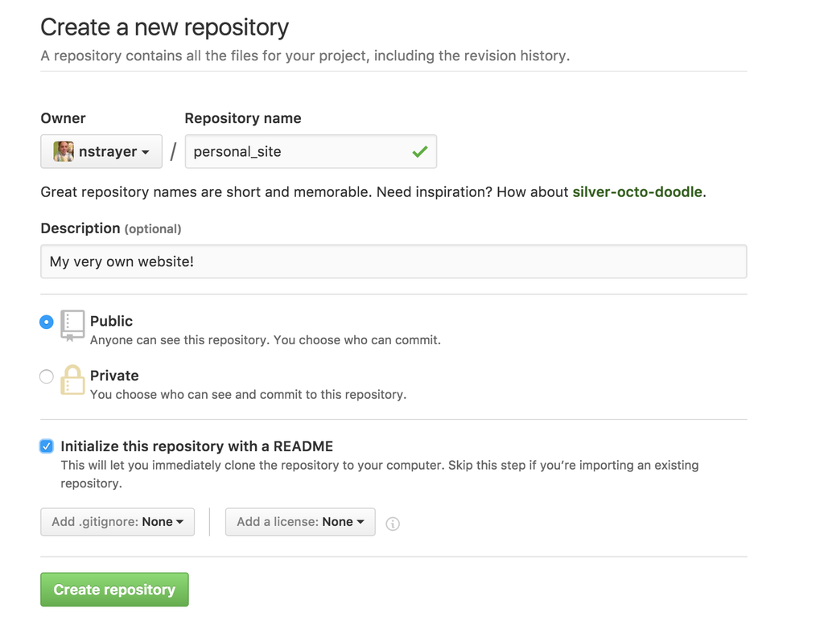

Now select “Clone or download” and copy the link that pops up.

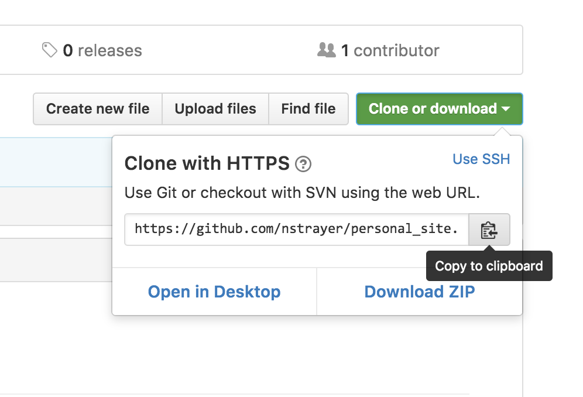

Now open your terminal, navigate to the area where you want to story your website on your local computer and then type in…

```bash
git clone https://github.com/nstrayer/personal_site.git  #<- Replace this with your personal link.
```

Once all the cool looking stuff finishes running on your terminal we must make a new branch. This is the super secret step that allows you to host websites on github.

```bash
cd personal_site/  #<- Again, replace this with your own folder name
git checkout -b gh-pages
```

These commands navigate into your new repo, then make a new branch called `gh-pages` and enter it. This branch name is crutial so don’t change it. It’s what github looks for when deciding whether or not to host your site.

Okay good! Now we have a repo setup that allows us to host websites to it. Now let’s actually get a website on it!

## Start your Markdowns!

First we do some administrative work to make sure we dont run into roadblocks on the way. Let’s update our `rmarkdown` package to make sure we actually have the version that supports rmarkdown websites.

```r
install.packages("rmarkdown", type = "source")
```

Next we need to create a couple empty files inside your repository.

```bash
touch _site.yml #"YML" file that tells your website how to assemble itself
touch index.Rmd #Create the main rmd file
touch about.Rmd #Create an about file
```

Now open all of these files in rstudio.

We will start by filling out the `yml` file. `yml` files, while confusing looking at first, are basically a roadmap for R to know how to assemble your website.

_**site.yml**

```r
name: "nicks-website"
navbar:
  title: "Nicks Website"
  left:
    - text: "Home"
      href: index.html
    - text: "About Me"
      href: about.html
```

Next we will fill out the bare minimum for the `.Rmd` files.

**index.Rmd**

```r
---
title: "Nick's Website"
---

Hello, World!
```

**about.Rmd**

```r
---
title: "About Me"
---

Why I am awesome.
```

## Let’s build it!

Okay, one last step to actually have a functioning website. We need to actually turn these seperate files into a single cohesive website.

To do this we are going to create one more file. This time just a plain r script.

```bash
touch build_site.R
```

**build_site.R**

```r
#Set our working directory.
#This helps avoid confusion if our working directory is
#not our site because of other projects we were
#working on at the time.
setwd("/Users/Nick/personal_site")

#tender your sweet site.
rmarkdown::render_site()

#this moves the rendered site back into the main level
#of the repository. Ugly, but makes github easier.
system("ditto _site/ .")
#if this command does not work for you, simply open the _site
#folder and copy all the files into the main level of your repo.
```

As a note, you could skip this step if you had started by creating an rstudio project, however, by doing it this way we are not dependent upon rstudio itself. This could be helpeful if in the future you are doing this on a computer without rStudio. It also helps explain the process a little bit more.

Now if everything has gone according to plan, by running the code in `build_site.R` you should get a bunch of unintellegable output followed by the message : `Output created: _site/index.html`. If so, yay, if not, double check all the stuff above to make sure you followed it exactly. Or more likely I messed up and you should inform me.

Now we can open it up. Open the repository with `finder` or whatever tool your computer uses to look at files, then click on `index.html` and hopefully you should get something that looks like this.

[figure not shown]

Sweet. You have now created your own personal website. First let’s push it to github and then we can get down to making it good for you.

## Git it hosted

Now we just have to add commit and push everything to github. The one difference from normal is we have to make sure we are pushing to the gh-pages branch.

```bash
#Let's add all the files to our git staging area
git add -A #the -A flag tells it git you want everything

#Now we can commit
git commit -m "My first website commit. The begining of greatness"

#Now we push. Note the addendum to normal pushing
git push origin gh-pages
```

Now we can navigate to our hosted site! Open your browser of choice and go to `www.<your github name>.github.io/<your sites repo name>`. (E.g. `www.nstrayer.github.io/personal_site`).

*Note: github has to build stuff on its end so it may take a minute or so for stuff to show up. Just keep impatiently refreshing the page and it will go faster.*